# IE 360 Term Project Report

GROUP1: Ayşegül ARABACI, Berker ALP, Ulaş Diyar ÖNDER

07/05/2024

## Introduction:

In this project, the main goal is to predict the hourly solar power production of Edikli GES that is located in Niğde at 38.29 North, 34.97 East between May 13 and May 26. Requirement of the task is prediction T+1 period ahead using given production data from T-1 before and given other data.

We have past solar power production data of the facility. In addition to this, there are ten variables about weather conditions. These are about radiation flux, being cloudy or not, being snowy or not, humidity and temperature. Detail od These data are:

DSWRF_surface: Radiation flux.

USWRF_top_of_atmosphere, USWRF_surface, DLWRF_surface: Solar radiation related variables.

TCDC_low.cloud.layer, TCDC_middle.cloud.layer, TCDC_high.cloud.layer, TCDC_entire.atmosphere: total cloud data at given level at atmosphere.

CSNOW_surface: Solar panel covered by snow or not

TMP_surface: Surface temperature

There are 25 locations near the facility that have this data, in this project average of data for 25 locations calculated and the average accepted for prediction calculations.

##Data Loading

```
##          date  hour production            datetime
##        <Date> <int>      <num>              <POSc>
## 1: 2022-01-01    10       9.38 2022-01-01 10:00:00
## 2: 2022-01-01    11       7.65 2022-01-01 11:00:00
## 3: 2022-01-01    12       6.80 2022-01-01 12:00:00
## 4: 2022-01-01    13       5.10 2022-01-01 13:00:00
## 5: 2022-01-01    14       5.10 2022-01-01 14:00:00
## 6: 2022-01-01    15       1.70 2022-01-01 15:00:00
```

```
##          date  hour production            datetime
##        <Date> <int>      <num>              <POSc>
## 1: 2024-04-16    18       0.03 2024-04-16 18:00:00
## 2: 2024-04-16    19       0.00 2024-04-16 19:00:00
## 3: 2024-04-16    20       0.00 2024-04-16 20:00:00
## 4: 2024-04-16    21       0.00 2024-04-16 21:00:00
## 5: 2024-04-16    22       0.00 2024-04-16 22:00:00
## 6: 2024-04-16    23       0.00 2024-04-16 23:00:00
```

```
##          date  hour   lat   lon DSWRF_surface TCDC_low.cloud.layer
##        <Date> <int> <num> <num>         <num>                <num>
## 1: 2023-07-12    10 37.75 34.50       718.080                  0.0
## 2: 2022-10-25    14 37.75 34.75       608.080                  0.0
## 3: 2022-10-25    15 37.75 34.50       590.592                  0.0
## 4: 2022-06-23     2 37.75 34.75         0.000                  9.7
## 5: 2022-06-26     3 37.75 34.50         0.000                 50.6
## 6: 2022-08-20     9 37.75 34.75       120.464                  0.0
##    TCDC_middle.cloud.layer TCDC_high.cloud.layer TCDC_entire.atmosphere
##                      <num>                 <num>                  <num>
## 1:                     0.0                     0                    0.0
## 2:                     0.0                     0                    0.0
## 3:                     0.0                     0                    0.0
## 4:                    13.9                     0                   17.9
## 5:                    42.4                     0                   52.0
```

[output cut: 17 more lines]

## Plot of Production and Autocorelation

According to past data, seasonality can be observed naturally because the productions are made according to weather conditions and the weather conditions are similar from year to year. They change from certain times because of seasons( winter, spring, summer and fall). In addition, the hourly effect of the sun can be observed (day-night). After some examinations and tabulations of the data, we can check the autocorrelation, seasonality and trend. According to tables and graphs created for checking these things, we can see that autocorrelation, seasonality and trend exist for these past production data.

We can see the similar patterns between autocorrelation and production graphs. Especially 1 hour, 24 hour(day) and 1 year effect can be seen. So we suggest that how much electricity is produced can be determined by production 1 hour, 24 hour, 1 year before. Since, main factor of production which is sun has seasons, the production should have the same seasons.

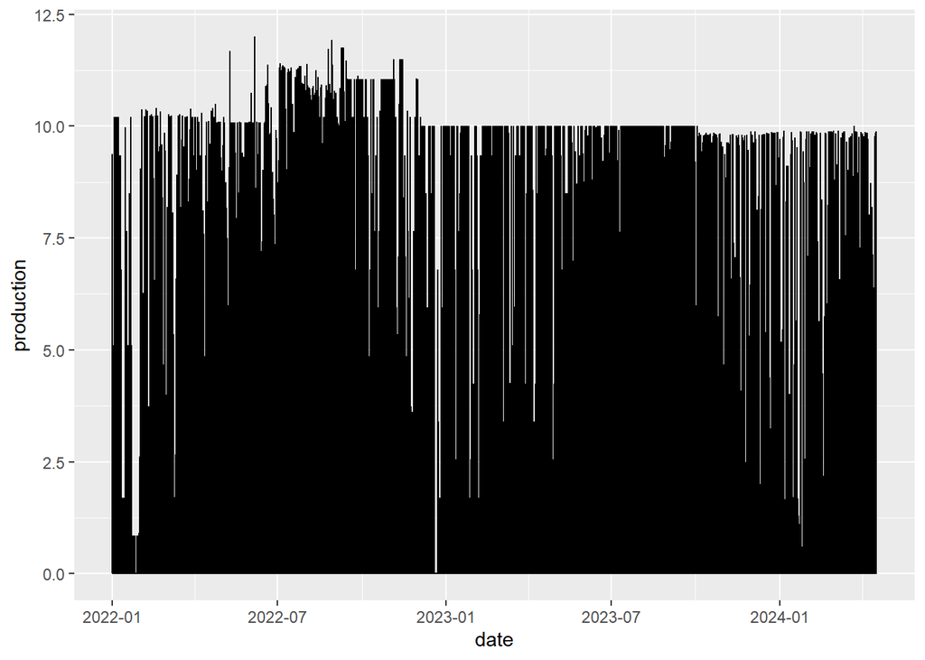

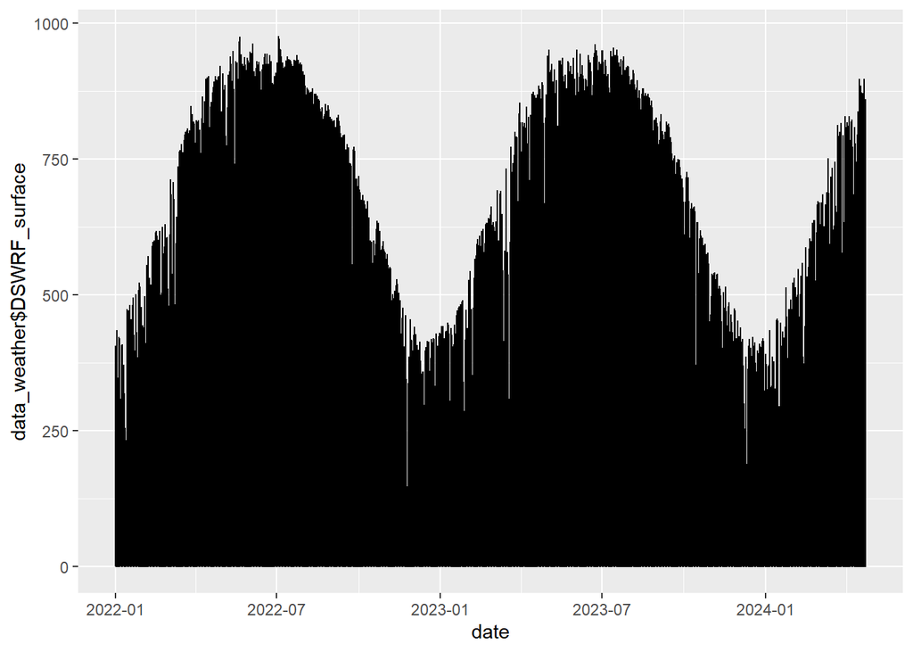

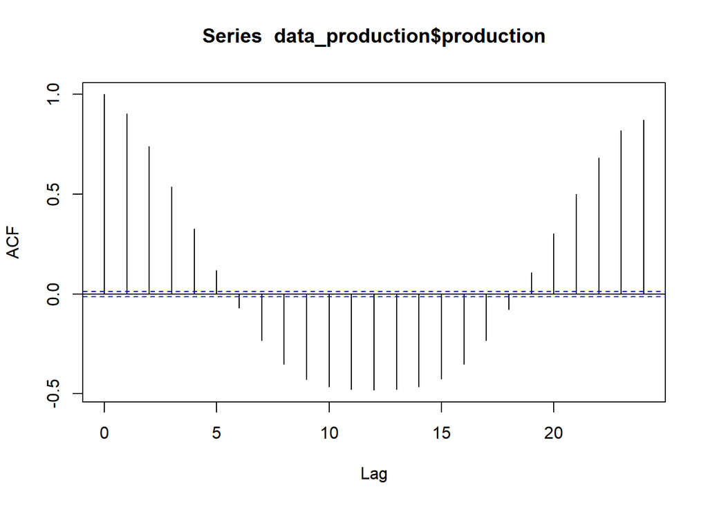

```r
acf(data_production$production,24) # 1 day
```

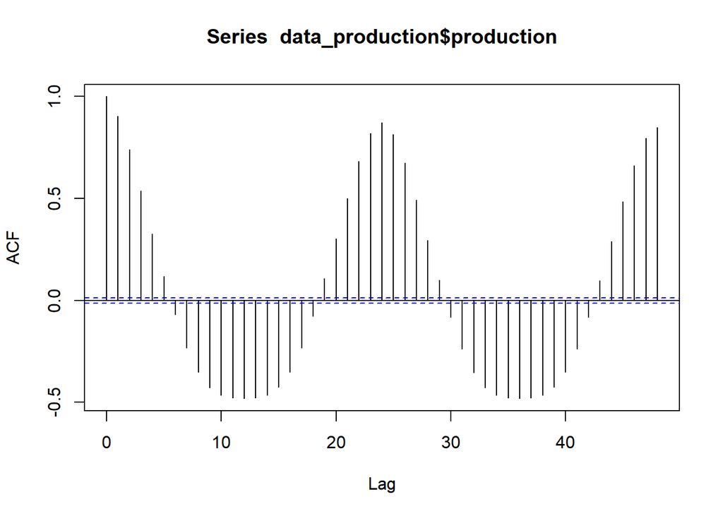

```r
acf(data_production$production,48) #2 day
```

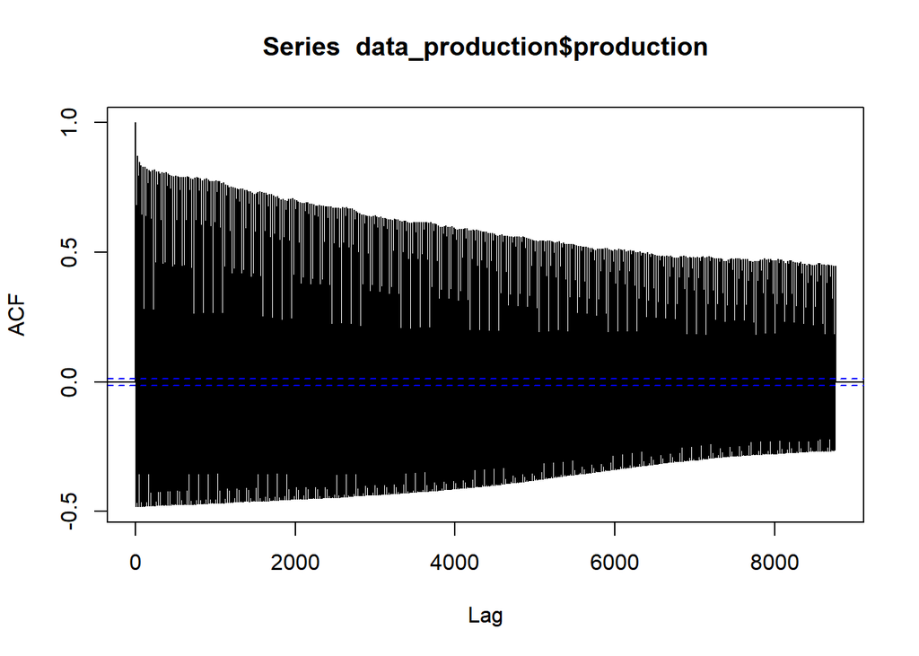

```r
acf(data_production$production,8760) #365 day
```

Since we have 25 locations with similar weather data, we decided to use average of all locations which is locations at solar production facility.

```r
#average of all panels, instead of the code above
avr_data <- data_weather %>%
  group_by(datetime) %>%
  summarise(
    average_DSWRF_surface = mean(DSWRF_surface, na.rm = TRUE),
    average_TCDC_low.cloud.layer = mean(TCDC_low.cloud.layer, na.rm = TRUE),
    average_TCDC_middle.cloud.layer = mean(TCDC_middle.cloud.layer, na.rm = TRUE),
    average_TCDC_high.cloud.layer = mean(TCDC_high.cloud.layer, na.rm = TRUE),
    average_TCDC_entire.atmosphere = mean(TCDC_entire.atmosphere, na.rm = TRUE),
    average_USWRF_top.of.atmosphere = mean(USWRF_top_of_atmosphere, na.rm = TRUE),
    average_CSNOW.surface = mean(CSNOW_surface, na.rm = TRUE),
    average_DLWRF.surface = mean(DLWRF_surface, na.rm = TRUE),
    average_USWRF.surface = mean(USWRF_surface, na.rm = TRUE),
    average_TMP.surface = mean(TMP_surface, na.rm = TRUE),
  )
avr_data <- full_join(data_production,avr_data,by='datetime')
head(avr_data)
```

```
##          date  hour production            datetime average_DSWRF_surface
##        <Date> <int>      <num>              <POSc>                 <num>
## 1: 2022-01-01    10       9.38 2022-01-01 10:00:00              180.1384
## 2: 2022-01-01    11       7.65 2022-01-01 11:00:00              254.7928
## 3: 2022-01-01    12       6.80 2022-01-01 12:00:00              312.5520
## 4: 2022-01-01    13       5.10 2022-01-01 13:00:00              347.4144
## 5: 2022-01-01    14       5.10 2022-01-01 14:00:00              364.6544
## 6: 2022-01-01    15       1.70 2022-01-01 15:00:00              362.2984
##    average_TCDC_low.cloud.layer average_TCDC_middle.cloud.layer
##                           <num>                           <num>
## 1:                        4.180                          13.748
## 2:                        3.972                          16.520
## 3:                        4.408                          23.468
## 4:                        5.348                          32.996
## 5:                        6.772                          39.460
```

[output cut: 25 more lines]

## Cloud Corelation

Here, we check correlation of cloud with production. From the table, we see that each cloud data is correlated to production and each other. Due to multicorelianithy effect, we only selected average_TCDC_entire.atmosphere which is most correlated with production. Since the production is dependent to sun light and clouds one of the factors that covers sun lights, this correlation sounds like logical causation even though they are not strongly correlated.

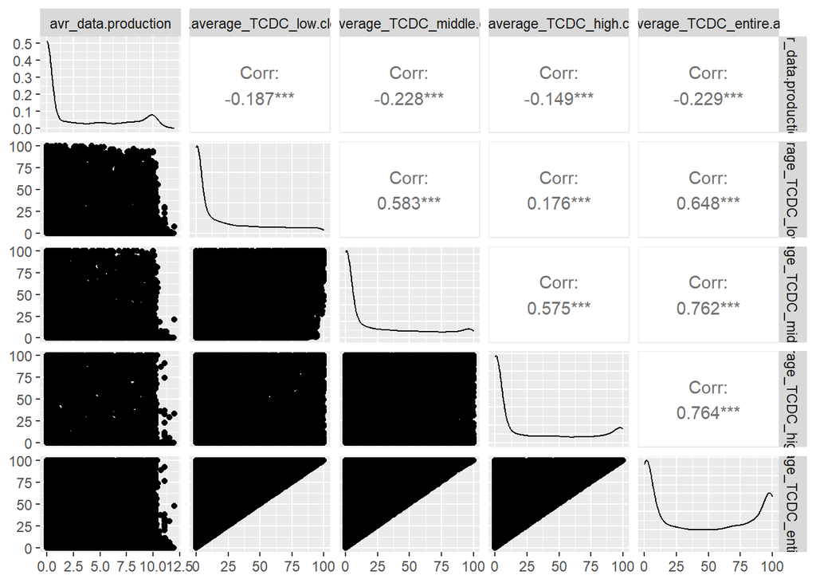

```r
TCDC <- data.frame(avr_data$production,avr_data$average_TCDC_low.cloud.layer,avr_data$average_TCDC_middle.cloud.layer,avr_data$average_TCDC_high.cloud.layer,avr_data$average_TCDC_entire.atmosphere)
ggpairs(TCDC)
```

## Surface Flux Tempature Radiotion etc.

Similar to cloud effect we checked correlation for the rests. From the plot we can see multicolinearity problem exits. Because of that we decided to select most correlated data to production. They are average_TCDC_entire.atmosphere,average_USWRF.surface,average_TMP.surface,average_DSWRF_surface. Due to multicolinearity, we might able to use one of them. They are sun light dependent data so they sounds like suitable for the production prediction.

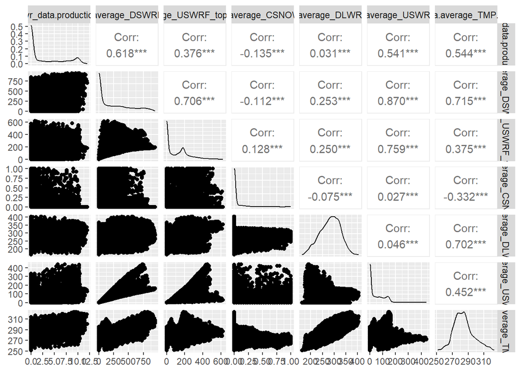

```r
surface <- data.frame(avr_data$production,avr_data$average_DSWRF_surface,avr_data$average_USWRF_top.of.atmosphere,avr_data$average_CSNOW.surface,avr_data$average_DLWRF.surface,avr_data$average_USWRF.surface,avr_data$average_TMP.surface)
ggpairs(surface)
```

## Data Maniplation for Model Construction

At that point we filtered our data set to include : datetime : Hour-Day-Month-Year of row production: Energy production average_TCDC_entire.atmosphere: Average cloud in entire atmosphere average_USWRF.surface: Solar radiation average_TMP.surface: Temperature average_DSWRF_surface: Radiation flux

In addition we add seasonality variables we talk about at autoelation table explanation: day: day at datetime(useful for year effect) hour: hour at datetime(useful for day and night difference) month: month at datetime(useful for season)

Finally,we also decided to previous production as variables because of autocorelation. Since previous production might have similar weather, season effect, it might be useful for model development. These previous productions are lag1: 1 hour before production lag48: 48 hour before production lag72: 72 hour before production

At competition phase, we will be able to get 48 hour ago production data from the day we predict. Since the newest data has 48 hour ago production at least lag48 we can use. However we decided to use lag1 to test our hypothesis previous production is crious to predict next hour.

```r
model <-avr_data %>% select(datetime,production,average_TCDC_entire.atmosphere,average_USWRF.surface,average_TMP.surface,average_DSWRF_surface)
head(model)
```

```
##               datetime production average_TCDC_entire.atmosphere
##                 <POSc>      <num>                          <num>
## 1: 2022-01-01 10:00:00       9.38                         85.364
## 2: 2022-01-01 11:00:00       7.65                         75.468
## 3: 2022-01-01 12:00:00       6.80                         70.368
## 4: 2022-01-01 13:00:00       5.10                         70.452
## 5: 2022-01-01 14:00:00       5.10                         71.136
## 6: 2022-01-01 15:00:00       1.70                         71.612
##    average_USWRF.surface average_TMP.surface average_DSWRF_surface
##                    <num>               <num>                 <num>
## 1:              59.18848             275.786              180.1384
## 2:              82.53120             278.553              254.7928
## 3:              99.73056             280.215              312.5520
## 4:             109.43168             280.609              347.4144
## 5:             113.51040             280.277              364.6544
## 6:             112.10304             279.165              362.2984
```

```r
# Dummy Variables
model$day <- yday(model$datetime) #day variable
model$hour <- hour(model$datetime) #hour variable
model$month <- month(model$datetime) #month variable

model$day <- as.character(model$day)
model$hour <- as.character(model$hour)
model$month <- as.character(model$month)
head(model,50)
```

```
##                datetime production average_TCDC_entire.atmosphere
##                  <POSc>      <num>                          <num>
##  1: 2022-01-01 10:00:00       9.38                         85.364
##  2: 2022-01-01 11:00:00       7.65                         75.468
##  3: 2022-01-01 12:00:00       6.80                         70.368
##  4: 2022-01-01 13:00:00       5.10                         70.452
##  5: 2022-01-01 14:00:00       5.10                         71.136
##  6: 2022-01-01 15:00:00       1.70                         71.612
##  7: 2022-01-01 16:00:00       0.00                         89.116
##  8: 2022-01-01 17:00:00       0.00                         85.688
##  9: 2022-01-01 18:00:00       0.00                         83.300
## 10: 2022-01-01 19:00:00       0.00                         83.508
## 11: 2022-01-01 20:00:00       0.00                         85.644
## 12: 2022-01-01 21:00:00       0.00                         87.520
## 13: 2022-01-01 22:00:00       0.00                         98.276
```

[output cut: 144 more lines]

```r
#Lag difference
model[is.na(model)] <- 0
model$lag48[49:20268] = model$production[1:20220] #48 hour
model$lag49[50:20268] = model$production[1:20219] #49 hour
model$lag47[48:20268] = model$production[1:20221] #47 hour
model$lag72[73:20268] = model$production[1:20196] #72 hour
model$lag1[2:20268] = model$production[1:20267] # 1 hour
summary(model)
```

```
##     datetime                        production
##  Min.   :2022-01-01 04:00:00.00   Min.   : 0.000
##  1st Qu.:2022-07-31 06:45:00.00   1st Qu.: 0.000
##  Median :2023-02-26 09:30:00.00   Median : 0.000
##  Mean   :2023-02-26 16:41:41.24   Mean   : 2.553
##  3rd Qu.:2023-09-25 12:15:00.00   3rd Qu.: 5.100
##  Max.   :2024-04-22 15:00:00.00   Max.   :12.000
##
##  average_TCDC_entire.atmosphere average_USWRF.surface average_TMP.surface
##  Min.   :  0.000                Min.   :  0.00        Min.   :  0.0
##  1st Qu.:  3.627                1st Qu.:  0.00        1st Qu.:275.7
##  Median : 40.178                Median : 18.09        Median :282.9
##  Mean   : 44.760                Mean   : 49.34        Mean   :284.2
##  3rd Qu.: 84.680                3rd Qu.: 89.63        3rd Qu.:290.7
##  Max.   :100.000                Max.   :441.61        Max.   :323.2
##
##  average_DSWRF_surface     day                hour              month
##  Min.   :  0.00        Length:20268       Length:20268       Length:20268
##  1st Qu.:  0.00        Class :character   Class :character   Class :character
##  Median : 75.04        Mode  :character   Mode  :character   Mode  :character
##  Mean   :215.65
##  3rd Qu.:386.66
##  Max.   :949.66
##
##      lag48            lag49            lag47            lag72
##  Min.   : 0.000   Min.   : 0.000   Min.   : 0.000   Min.   : 0.000
##  1st Qu.: 0.000   1st Qu.: 0.000   1st Qu.: 0.000   1st Qu.: 0.000
##  Median : 0.000   Median : 0.000   Median : 0.000   Median : 0.000
##  Mean   : 2.559   Mean   : 2.559   Mean   : 2.559   Mean   : 2.562
##  3rd Qu.: 5.100   3rd Qu.: 5.100   3rd Qu.: 5.100   3rd Qu.: 5.100
##  Max.   :12.000   Max.   :12.000   Max.   :12.000   Max.   :12.000
##  NA's   :48       NA's   :49       NA's   :47       NA's   :72
##       lag1
##  Min.   : 0.000
##  1st Qu.: 0.000
##  Median : 0.000
##  Mean   : 2.553
##  3rd Qu.: 5.100
##  Max.   :12.000
##  NA's   :1
```

## Linear Models Constructions

At that phase, we constructed many different models with the variables we defined before. First of all we focused on R^2 of each model, residual distribution and capacity to use the model at competition phase.

At lm_demo1 we used that: -48 hour before production -Average radiation flux -Cloud at entire atmosphere -hour seasonality variable At the model we still have autocorelation at lag 1 and lag 24. Unfortunately we won’t have production at these hours so we can’t eliminate that. On the other hand, the distribution of the residual likes norm at expect the center of the distribution.

```r
# lag 48 model
lm_demo1=lm(production~lag48+hour +average_DSWRF_surface+average_TCDC_entire.atmosphere,data = model)
summary(lm_demo1)
```

```
##
## Call:
## lm(formula = production ~ lag48 + hour + average_DSWRF_surface +
##     average_TCDC_entire.atmosphere, data = model)
##
## Residuals:
##     Min      1Q  Median      3Q     Max
## -9.7796 -0.4123  0.0570  0.5802  8.3460
##
## Coefficients:
##                                  Estimate Std. Error t value Pr(>|t|)
## (Intercept)                     4.085e-01  5.523e-02   7.396 1.46e-13 ***
## lag48                           2.857e-01  6.100e-03  46.828  < 2e-16 ***
## hour1                          -5.327e-03  7.566e-02  -0.070    0.944
## hour10                          3.797e+00  9.243e-02  41.085  < 2e-16 ***
## hour11                          3.571e+00  9.464e-02  37.733  < 2e-16 ***
## hour12                          3.275e+00  9.628e-02  34.013  < 2e-16 ***
## hour13                          2.829e+00  9.682e-02  29.221  < 2e-16 ***
## hour14                          2.011e+00  9.578e-02  21.001  < 2e-16 ***
## hour15                          7.618e-01  9.364e-02   8.135 4.35e-16 ***
## hour16                         -1.182e-01  8.640e-02  -1.369    0.171
## hour17                         -8.960e-01  8.349e-02 -10.732  < 2e-16 ***
## hour18                         -1.143e+00  8.116e-02 -14.080  < 2e-16 ***
## hour19                         -9.391e-01  7.926e-02 -11.848  < 2e-16 ***
## hour2                          -9.255e-03  7.566e-02  -0.122    0.903
## hour20                         -7.493e-01  7.805e-02  -9.600  < 2e-16 ***
## hour21                         -6.199e-01  7.734e-02  -8.015 1.16e-15 ***
## hour22                          1.013e-02  7.566e-02   0.134    0.893
## hour23                          6.039e-03  7.566e-02   0.080    0.936
## hour3                          -1.090e-02  7.566e-02  -0.144    0.885
## hour4                          -1.058e-02  7.564e-02  -0.140    0.889
## hour5                           2.621e-02  7.564e-02   0.347    0.729
## hour6                           4.020e-01  7.572e-02   5.309 1.11e-07 ***
## hour7                           1.908e+00  7.742e-02  24.652  < 2e-16 ***
## hour8                           3.709e+00  8.219e-02  45.128  < 2e-16 ***
## hour9                           4.897e+00  8.701e-02  56.275  < 2e-16 ***
## average_DSWRF_surface           4.107e-03  9.321e-05  44.062  < 2e-16 ***
## average_TCDC_entire.atmosphere -9.342e-03  3.125e-04 -29.890  < 2e-16 ***
## ---
## Signif. codes:  0 '***' 0.001 '**' 0.01 '*' 0.05 '.' 0.1 ' ' 1
##
## Residual standard error: 1.552 on 20193 degrees of freedom
##   (48 observations deleted due to missingness)
## Multiple R-squared:  0.8238, Adjusted R-squared:  0.8236
## F-statistic:  3632 on 26 and 20193 DF,  p-value: < 2.2e-16
```

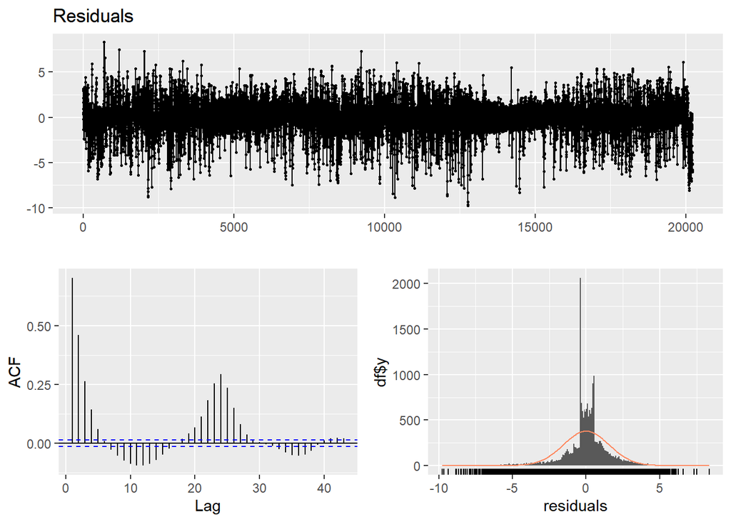

```
##
##  Breusch-Godfrey test for serial correlation of order up to 30
##
## data:  Residuals
## LM test = 10592, df = 30, p-value < 2.2e-16
```

```r
checkresiduals(lm_demo1)
```

lm_demo1_1 It is lm_demo1 with lag72. The results are similar to lm_demo1 but better R^2.

```r
# lag48-72 model
lm_demo1_1=lm(production~lag48+lag72+ hour +average_DSWRF_surface+average_TCDC_entire.atmosphere,data = model)
summary(lm_demo1_1)
```

```
##
## Call:
## lm(formula = production ~ lag48 + lag72 + hour + average_DSWRF_surface +
##     average_TCDC_entire.atmosphere, data = model)
##
## Residuals:
##     Min      1Q  Median      3Q     Max
## -9.4501 -0.4031  0.0581  0.5560  8.5163
##
## Coefficients:
##                                  Estimate Std. Error t value Pr(>|t|)
## (Intercept)                     4.008e-01  5.465e-02   7.333 2.33e-13 ***
## lag48                           2.181e-01  6.809e-03  32.034  < 2e-16 ***
## lag72                           1.438e-01  6.731e-03  21.365  < 2e-16 ***
## hour1                          -6.520e-03  7.487e-02  -0.087   0.9306
## hour10                          3.321e+00  9.410e-02  35.295  < 2e-16 ***
## hour11                          3.108e+00  9.608e-02  32.351  < 2e-16 ***
## hour12                          2.836e+00  9.742e-02  29.110  < 2e-16 ***
## hour13                          2.434e+00  9.755e-02  24.947  < 2e-16 ***
## hour14                          1.702e+00  9.587e-02  17.754  < 2e-16 ***
## hour15                          5.900e-01  9.302e-02   6.343 2.31e-10 ***
## hour16                         -1.645e-01  8.555e-02  -1.923   0.0545 .
## hour17                         -8.502e-01  8.268e-02 -10.284  < 2e-16 ***
## hour18                         -1.060e+00  8.043e-02 -13.185  < 2e-16 ***
## hour19                         -8.695e-01  7.852e-02 -11.073  < 2e-16 ***
## hour2                          -1.157e-02  7.487e-02  -0.155   0.8771
## hour20                         -6.931e-01  7.729e-02  -8.967  < 2e-16 ***
## hour21                         -5.729e-01  7.658e-02  -7.482 7.62e-14 ***
## hour22                          1.073e-02  7.487e-02   0.143   0.8861
## hour23                          6.619e-03  7.487e-02   0.088   0.9296
## hour3                          -1.352e-02  7.487e-02  -0.181   0.8567
## hour4                          -1.338e-02  7.485e-02  -0.179   0.8581
## hour5                           1.990e-02  7.485e-02   0.266   0.7903
## hour6                           3.565e-01  7.497e-02   4.755 2.00e-06 ***
## hour7                           1.704e+00  7.723e-02  22.065  < 2e-16 ***
## hour8                           3.311e+00  8.351e-02  39.652  < 2e-16 ***
## hour9                           4.363e+00  8.971e-02  48.638  < 2e-16 ***
## average_DSWRF_surface           3.821e-03  9.333e-05  40.944  < 2e-16 ***
## average_TCDC_entire.atmosphere -9.197e-03  3.096e-04 -29.711  < 2e-16 ***
## ---
## Signif. codes:  0 '***' 0.001 '**' 0.01 '*' 0.05 '.' 0.1 ' ' 1
##
## Residual standard error: 1.535 on 20168 degrees of freedom
##   (72 observations deleted due to missingness)
## Multiple R-squared:  0.8277, Adjusted R-squared:  0.8275
## F-statistic:  3588 on 27 and 20168 DF,  p-value: < 2.2e-16
```

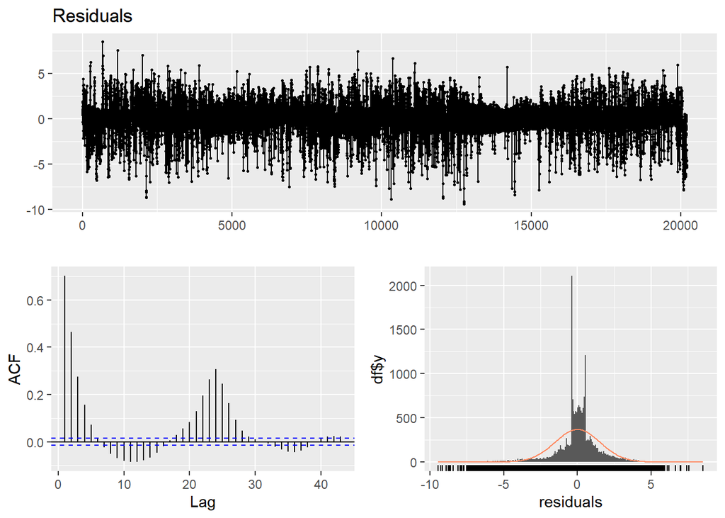

```
##
##  Breusch-Godfrey test for serial correlation of order up to 31
##
## data:  Residuals
## LM test = 10600, df = 31, p-value < 2.2e-16
```

```r
checkresiduals(lm_demo1_1)
```

lm_demo2 This model build on lm_demo1 with the all variables we talk about. As we mentioned, using all of the variables from the data set are problematic due to multicolinearity. In that model we tested effect of multicolinearity and we seen that model is not better than lm_demo1. More autocorelation especially between 10 and 20 hour seen and no improvement at distribution of residuals.

```r
#Sesonality plus lag48 extra variable
lm_demo2=lm(production~hour +month+ lag48 + average_TCDC_entire.atmosphere + average_USWRF.surface + average_TMP.surface ,data = model)
summary(lm_demo2)
```

```
##
## Call:
## lm(formula = production ~ hour + month + lag48 + average_TCDC_entire.atmosphere +
##     average_USWRF.surface + average_TMP.surface, data = model)
##
## Residuals:
##     Min      1Q  Median      3Q     Max
## -9.1463 -0.5478  0.0481  0.7016 23.2361
##
## Coefficients:
##                                  Estimate Std. Error t value Pr(>|t|)
## (Intercept)                    -1.796e+01  5.746e-01 -31.254  < 2e-16 ***
## hour1                           2.078e-02  7.560e-02   0.275  0.78339
## hour10                          4.005e+00  9.673e-02  41.403  < 2e-16 ***
## hour11                          3.736e+00  1.000e-01  37.361  < 2e-16 ***
## hour12                          3.438e+00  1.022e-01  33.630  < 2e-16 ***
## hour13                          3.028e+00  1.027e-01  29.481  < 2e-16 ***
## hour14                          2.274e+00  1.008e-01  22.572  < 2e-16 ***
## hour15                          1.133e+00  9.661e-02  11.730  < 2e-16 ***
## hour16                          3.956e-02  8.916e-02   0.444  0.65722
## hour17                         -7.043e-01  8.472e-02  -8.314  < 2e-16 ***
## hour18                         -8.973e-01  8.125e-02 -11.044  < 2e-16 ***
## hour19                         -6.635e-01  7.894e-02  -8.405  < 2e-16 ***
## hour2                           4.196e-02  7.561e-02   0.555  0.57891
## hour20                         -4.729e-01  7.765e-02  -6.089 1.15e-09 ***
## hour21                         -3.705e-01  7.700e-02  -4.811 1.51e-06 ***
## hour22                         -4.810e-02  7.562e-02  -0.636  0.52469
## hour23                         -2.212e-02  7.560e-02  -0.293  0.76980
## hour3                           6.348e-02  7.563e-02   0.839  0.40132
## hour4                           8.667e-02  7.564e-02   1.146  0.25187
## hour5                           1.438e-01  7.567e-02   1.901  0.05737 .
## hour6                           5.246e-01  7.581e-02   6.920 4.64e-12 ***
## hour7                           1.957e+00  7.754e-02  25.242  < 2e-16 ***
## hour8                           3.610e+00  8.248e-02  43.773  < 2e-16 ***
## hour9                           4.606e+00  8.795e-02  52.369  < 2e-16 ***
## month10                        -4.730e-01  6.078e-02  -7.783 7.41e-15 ***
## month11                        -3.017e-01  5.551e-02  -5.434 5.56e-08 ***
## month12                        -1.030e-01  5.286e-02  -1.949  0.05134 .
## month2                          2.715e-01  4.891e-02   5.551 2.88e-08 ***
## month3                          1.561e-01  4.890e-02   3.192  0.00141 **
## month4                         -4.035e-01  5.593e-02  -7.214 5.61e-13 ***
## month5                         -3.612e-01  6.177e-02  -5.847 5.08e-09 ***
## month6                         -7.150e-01  6.792e-02 -10.527  < 2e-16 ***
## month7                         -9.870e-01  7.415e-02 -13.311  < 2e-16 ***
## month8                         -1.302e+00  7.902e-02 -16.475  < 2e-16 ***
## month9                         -8.772e-01  7.035e-02 -12.470  < 2e-16 ***
## lag48                           2.796e-01  6.288e-03  44.460  < 2e-16 ***
## average_TCDC_entire.atmosphere -1.201e-02  3.446e-04 -34.856  < 2e-16 ***
## average_USWRF.surface           8.751e-03  3.413e-04  25.641  < 2e-16 ***
## average_TMP.surface             6.758e-02  2.131e-03  31.714  < 2e-16 ***
## ---
## Signif. codes:  0 '***' 0.001 '**' 0.01 '*' 0.05 '.' 0.1 ' ' 1
##
## Residual standard error: 1.551 on 20181 degrees of freedom
##   (48 observations deleted due to missingness)
## Multiple R-squared:  0.8243, Adjusted R-squared:  0.8239
## F-statistic:  2491 on 38 and 20181 DF,  p-value: < 2.2e-16
```

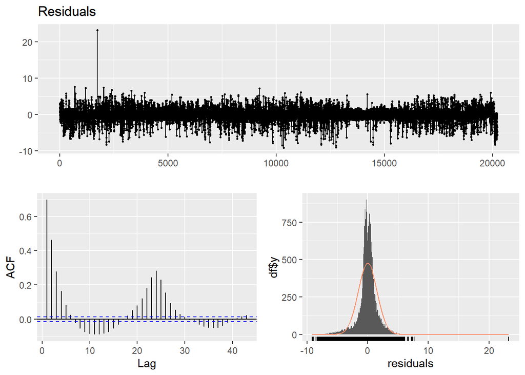

```
##
##  Breusch-Godfrey test for serial correlation of order up to 42
##
## data:  Residuals
## LM test = 10432, df = 42, p-value < 2.2e-16
```

```r
checkresiduals(lm_demo2)
```

```r
# lm_demo1 plus seasonality
lm_demo3=lm(production~lag48+hour+month+average_TCDC_entire.atmosphere,data = model)
summary(lm_demo3)
```

```
##
## Call:
## lm(formula = production ~ lag48 + hour + month + average_TCDC_entire.atmosphere,
##     data = model)
##
## Residuals:
##     Min      1Q  Median      3Q     Max
## -9.2882 -0.6741  0.0604  0.7861  7.7873
##
## Coefficients:
##                                  Estimate Std. Error t value Pr(>|t|)
## (Intercept)                     0.1233117  0.0673044   1.832  0.06694 .
## lag48                           0.3313484  0.0063159  52.463  < 2e-16 ***
## hour1                          -0.0070971  0.0782988  -0.091  0.92778
## hour10                          5.2244807  0.0927178  56.348  < 2e-16 ***
## hour11                          5.2783717  0.0929471  56.789  < 2e-16 ***
## hour12                          5.2082569  0.0925621  56.268  < 2e-16 ***
## hour13                          4.9283023  0.0911213  54.085  < 2e-16 ***
## hour14                          4.2242169  0.0878623  48.078  < 2e-16 ***
## hour15                          3.0387237  0.0833119  36.474  < 2e-16 ***
## hour16                          1.6786939  0.0797392  21.052  < 2e-16 ***
## hour17                          0.6615909  0.0785212   8.426  < 2e-16 ***
## hour18                          0.1458746  0.0783388   1.862  0.06260 .
## hour19                          0.0945998  0.0783331   1.208  0.22719
## hour2                          -0.0122804  0.0782990  -0.157  0.87537
## hour20                          0.0883183  0.0783286   1.128  0.25953
## hour21                          0.0804664  0.0783234   1.027  0.30426
## hour22                          0.0152265  0.0782994   0.194  0.84581
## hour23                          0.0091747  0.0782990   0.117  0.90672
## hour3                          -0.0145363  0.0782991  -0.186  0.85272
## hour4                          -0.0151628  0.0782763  -0.194  0.84641
## hour5                           0.0187298  0.0782777   0.239  0.81090
## hour6                           0.3733649  0.0783672   4.764 1.91e-06 ***
## hour7                           1.8176128  0.0801725  22.671  < 2e-16 ***
## hour8                           3.5943935  0.0853813  42.098  < 2e-16 ***
## hour9                           4.8595665  0.0908257  53.504  < 2e-16 ***
## month10                         0.4768889  0.0546185   8.731  < 2e-16 ***
## month11                         0.1757048  0.0544434   3.227  0.00125 **
## month12                         0.0637341  0.0538575   1.183  0.23667
## month2                          0.5401943  0.0493486  10.947  < 2e-16 ***
## month3                          0.6893855  0.0484682  14.223  < 2e-16 ***
## month4                          0.5899136  0.0501251  11.769  < 2e-16 ***
## month5                          0.7739037  0.0543710  14.234  < 2e-16 ***
## month6                          0.7199312  0.0553626  13.004  < 2e-16 ***
## month7                          0.6943682  0.0579217  11.988  < 2e-16 ***
## month8                          0.5899559  0.0577173  10.221  < 2e-16 ***
## month9                          0.5634658  0.0573997   9.817  < 2e-16 ***
## average_TCDC_entire.atmosphere -0.0138660  0.0003496 -39.668  < 2e-16 ***
## ---
## Signif. codes:  0 '***' 0.001 '**' 0.01 '*' 0.05 '.' 0.1 ' ' 1
##
## Residual standard error: 1.607 on 20183 degrees of freedom
##   (48 observations deleted due to missingness)
## Multiple R-squared:  0.8114, Adjusted R-squared:  0.8111
## F-statistic:  2412 on 36 and 20183 DF,  p-value: < 2.2e-16
```

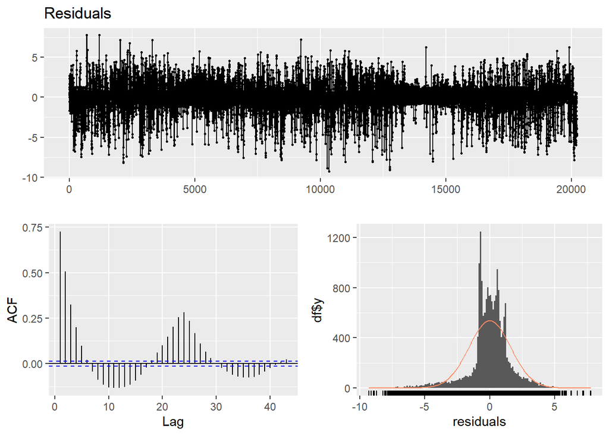

```
##
##  Breusch-Godfrey test for serial correlation of order up to 40
##
## data:  Residuals
## LM test = 11144, df = 40, p-value < 2.2e-16
```

```r
checkresiduals(lm_demo3)
```

lm_demo3_1 Similar to lm_demo3 but only lg-ag72 added instead of lag48. We won’t expect improvement at that model but it might be useful to understand auto regressive effect and use the model when 48 hour production data does not exits.

```r
#lm_demo3 with lag72
lm_demo3_1=lm(production~lag72+hour+month+average_TCDC_entire.atmosphere,data = model)
summary(lm_demo3_1)
```

```
##
## Call:
## lm(formula = production ~ lag72 + hour + month + average_TCDC_entire.atmosphere,
##     data = model)
##
## Residuals:
##     Min      1Q  Median      3Q     Max
## -9.0221 -0.7084  0.0711  0.8344  7.9523
##
## Coefficients:
##                                  Estimate Std. Error t value Pr(>|t|)
## (Intercept)                     0.0866633  0.0685693   1.264  0.20629
## lag72                           0.2861789  0.0063944  44.754  < 2e-16 ***
## hour1                          -0.0079864  0.0796588  -0.100  0.92014
## hour10                          5.5782884  0.0942129  59.209  < 2e-16 ***
## hour11                          5.6343252  0.0944441  59.658  < 2e-16 ***
## hour12                          5.5595858  0.0940484  59.114  < 2e-16 ***
## hour13                          5.2604207  0.0925949  56.811  < 2e-16 ***
## hour14                          4.5086276  0.0893098  50.483  < 2e-16 ***
## hour15                          3.2449552  0.0847093  38.307  < 2e-16 ***
## hour16                          1.7932792  0.0810964  22.113  < 2e-16 ***
## hour17                          0.7056849  0.0798793   8.834  < 2e-16 ***
## hour18                          0.1544388  0.0797002   1.938  0.05267 .
## hour19                          0.0995642  0.0796945   1.249  0.21156
## hour2                          -0.0142058  0.0796590  -0.178  0.85846
## hour20                          0.0928811  0.0796898   1.166  0.24382
## hour21                          0.0846029  0.0796843   1.062  0.28837
## hour22                          0.0161078  0.0796594   0.202  0.83976
## hour23                          0.0097428  0.0796589   0.122  0.90266
## hour3                          -0.0167419  0.0796592  -0.210  0.83354
## hour4                          -0.0170676  0.0796360  -0.214  0.83030
## hour5                           0.0200072  0.0796376   0.251  0.80164
## hour6                           0.3989088  0.0797297   5.003 5.68e-07 ***
## hour7                           1.9436264  0.0815526  23.833  < 2e-16 ***
## hour8                           3.8439092  0.0867955  44.287  < 2e-16 ***
## hour9                           5.1922931  0.0922925  56.259  < 2e-16 ***
## month10                         0.5381793  0.0556319   9.674  < 2e-16 ***
## month11                         0.2094336  0.0554663   3.776  0.00016 ***
## month12                         0.0882439  0.0548783   1.608  0.10785
## month2                          0.6047770  0.0502613  12.033  < 2e-16 ***
## month3                          0.7461411  0.0493778  15.111  < 2e-16 ***
## month4                          0.6504904  0.0510663  12.738  < 2e-16 ***
## month5                          0.8585319  0.0553270  15.517  < 2e-16 ***
## month6                          0.7880248  0.0563998  13.972  < 2e-16 ***
## month7                          0.7926601  0.0589755  13.441  < 2e-16 ***
## month8                          0.6683413  0.0588316  11.360  < 2e-16 ***
## month9                          0.6388194  0.0584934  10.921  < 2e-16 ***
## average_TCDC_entire.atmosphere -0.0143702  0.0003555 -40.423  < 2e-16 ***
## ---
## Signif. codes:  0 '***' 0.001 '**' 0.01 '*' 0.05 '.' 0.1 ' ' 1
##
## Residual standard error: 1.633 on 20159 degrees of freedom
##   (72 observations deleted due to missingness)
## Multiple R-squared:  0.805,  Adjusted R-squared:  0.8047
## F-statistic:  2312 on 36 and 20159 DF,  p-value: < 2.2e-16
```

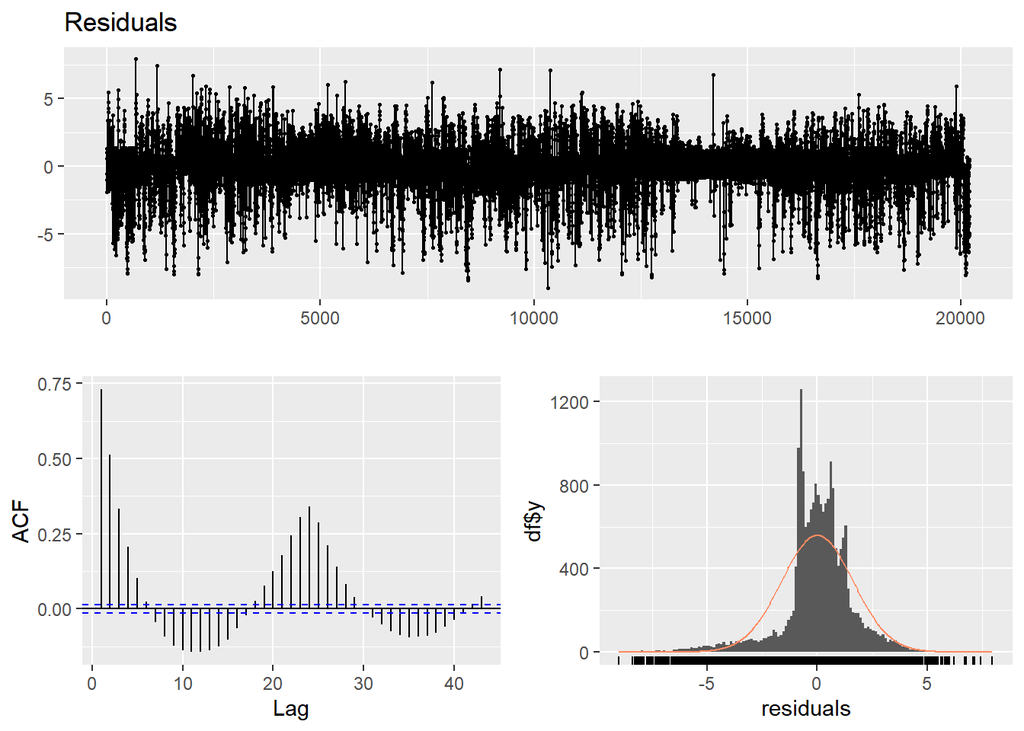

```
##
##  Breusch-Godfrey test for serial correlation of order up to 40
##
## data:  Residuals
## LM test = 11394, df = 40, p-value < 2.2e-16
```

```r
checkresiduals(lm_demo3_1)
```

lm_demo3_2 It is improved version of lm_demo3 with lag48 and lag72 together. Thanks to autoregressive effect, R^2 is 0.8165.However, similar problems we mentioned exitst.

```r
#lag48-72
lm_demo3_2=lm(production~lag72+lag48+hour+month+average_TCDC_entire.atmosphere,data = model)
summary(lm_demo3_2)
```

```
##
## Call:
## lm(formula = production ~ lag72 + lag48 + hour + month + average_TCDC_entire.atmosphere,
##     data = model)
##
## Residuals:
##     Min      1Q  Median      3Q     Max
## -9.3928 -0.6144  0.0528  0.7546  7.9941
##
## Coefficients:
##                                  Estimate Std. Error t value Pr(>|t|)
## (Intercept)                     0.1906481  0.0665309   2.866  0.00417 **
## lag72                           0.1710859  0.0069746  24.530  < 2e-16 ***
## lag48                           0.2522767  0.0070086  35.995  < 2e-16 ***
## hour1                          -0.0085816  0.0772178  -0.111  0.91151
## hour10                          4.5001459  0.0961122  46.822  < 2e-16 ***
## hour11                          4.5463864  0.0964102  47.157  < 2e-16 ***
## hour12                          4.4867229  0.0959150  46.778  < 2e-16 ***
## hour13                          4.2469411  0.0940700  45.147  < 2e-16 ***
## hour14                          3.6418545  0.0898597  40.528  < 2e-16 ***
## hour15                          2.6243329  0.0839042  31.278  < 2e-16 ***
## hour16                          1.4678603  0.0791295  18.550  < 2e-16 ***
## hour17                          0.5881165  0.0775005   7.589 3.38e-14 ***
## hour18                          0.1418902  0.0772587   1.837  0.06629 .
## hour19                          0.0966338  0.0772525   1.251  0.21099
## hour2                          -0.0151498  0.0772181  -0.196  0.84446
## hour20                          0.0901853  0.0772479   1.167  0.24303
## hour21                          0.0821896  0.0772426   1.064  0.28732
## hour22                          0.0160313  0.0772184   0.208  0.83554
## hour23                          0.0098758  0.0772179   0.128  0.89823
## hour3                          -0.0177712  0.0772182  -0.230  0.81798
## hour4                          -0.0187387  0.0771957  -0.243  0.80821
## hour5                           0.0108630  0.0771977   0.141  0.88809
## hour6                           0.3177263  0.0773195   4.109 3.98e-05 ***
## hour7                           1.5668216  0.0797436  19.648  < 2e-16 ***
## hour8                           3.1015597  0.0866266  35.804  < 2e-16 ***
## hour9                           4.1899511  0.0936979  44.718  < 2e-16 ***
## month10                         0.3954039  0.0540729   7.312 2.72e-13 ***
## month11                         0.1513887  0.0537908   2.814  0.00489 **
## month12                         0.0737344  0.0531982   1.386  0.16575
## month2                          0.5209371  0.0487768  10.680  < 2e-16 ***
## month3                          0.6421257  0.0479519  13.391  < 2e-16 ***
## month4                          0.5147335  0.0496449  10.368  < 2e-16 ***
## month5                          0.6900861  0.0538354  12.818  < 2e-16 ***
## month6                          0.6087503  0.0548979  11.089  < 2e-16 ***
## month7                          0.5348811  0.0576151   9.284  < 2e-16 ***
## month8                          0.4332646  0.0574015   7.548 4.61e-14 ***
## month9                          0.4213607  0.0570219   7.389 1.53e-13 ***
## average_TCDC_entire.atmosphere -0.0138800  0.0003449 -40.247  < 2e-16 ***
## ---
## Signif. codes:  0 '***' 0.001 '**' 0.01 '*' 0.05 '.' 0.1 ' ' 1
##
## Residual standard error: 1.583 on 20158 degrees of freedom
##   (72 observations deleted due to missingness)
## Multiple R-squared:  0.8168, Adjusted R-squared:  0.8165
## F-statistic:  2429 on 37 and 20158 DF,  p-value: < 2.2e-16
```

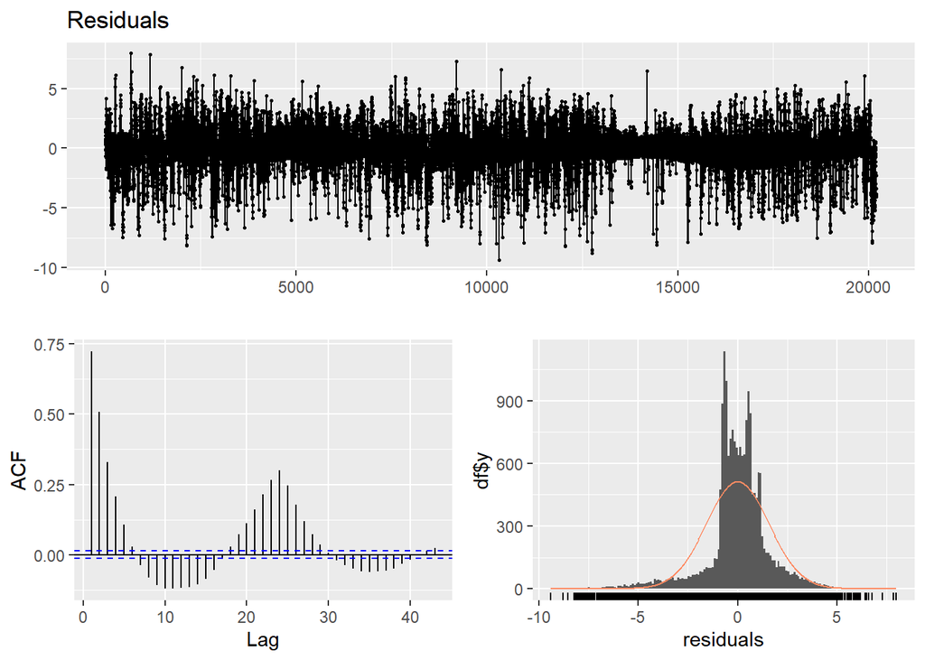

```
##
##  Breusch-Godfrey test for serial correlation of order up to 41
##
## data:  Residuals
## LM test = 11106, df = 41, p-value < 2.2e-16
```

```r
checkresiduals(lm_demo3_2)
```

lm_demo4 andlm_demo4_1 These two models uses lag1 which is 1 hour before production.Finally we see that if we add lag24 which is 24 before production we can most of the autocorelation problems. However, we know that at co petation phase we won’t have production data between 0-48 hour before interval. Other option is prediction these inteevals and using these predictions as variable. However, we increase error of the model adding prediction error at the variables.

```r
#lag1 plus seosonality
lm_demo4=lm(production~lag1+hour+month,data = model)
summary(lm_demo4)
```

```
##
## Call:
## lm(formula = production ~ lag1 + hour + month, data = model)
##
## Residuals:
##     Min      1Q  Median      3Q     Max
## -9.6921 -0.2326  0.0438  0.3073  8.6110
##
## Coefficients:
##               Estimate Std. Error t value Pr(>|t|)
## (Intercept) -2.293e-01  4.528e-02  -5.064 4.15e-07 ***
## lag1         7.700e-01  4.490e-03 171.488  < 2e-16 ***
## hour1       -5.708e-14  5.526e-02   0.000  1.00000
## hour10       2.252e+00  6.425e-02  35.055  < 2e-16 ***
## hour11       1.886e+00  6.559e-02  28.754  < 2e-16 ***
## hour12       1.717e+00  6.577e-02  26.102  < 2e-16 ***
## hour13       1.366e+00  6.550e-02  20.859  < 2e-16 ***
## hour14       6.354e-01  6.447e-02   9.856  < 2e-16 ***
## hour15      -3.483e-01  6.214e-02  -5.605 2.12e-08 ***
## hour16      -1.144e+00  5.889e-02 -19.423  < 2e-16 ***
## hour17      -9.750e-01  5.626e-02 -17.331  < 2e-16 ***
## hour18      -5.719e-01  5.539e-02 -10.326  < 2e-16 ***
## hour19      -5.247e-02  5.526e-02  -0.949  0.34242
## hour2       -1.390e-14  5.526e-02   0.000  1.00000
## hour20       2.073e-04  5.526e-02   0.004  0.99701
## hour21       2.529e-04  5.526e-02   0.005  0.99635
## hour22       2.529e-04  5.526e-02   0.005  0.99635
## hour23       2.529e-04  5.526e-02   0.005  0.99635
## hour3       -1.615e-13  5.526e-02   0.000  1.00000
## hour4        4.555e-03  5.525e-02   0.082  0.93428
## hour5        5.390e-02  5.525e-02   0.976  0.32929
## hour6        5.411e-01  5.525e-02   9.794  < 2e-16 ***
## hour7        2.286e+00  5.531e-02  41.329  < 2e-16 ***
## hour8        3.285e+00  5.660e-02  58.050  < 2e-16 ***
## hour9        3.138e+00  6.032e-02  52.016  < 2e-16 ***
## month10      2.593e-01  3.818e-02   6.792 1.14e-11 ***
## month11      1.008e-01  3.828e-02   2.633  0.00848 **
## month12      5.073e-02  3.786e-02   1.340  0.18025
## month2       1.583e-01  3.475e-02   4.557 5.22e-06 ***
## month3       1.810e-01  3.400e-02   5.323 1.03e-07 ***
## month4       2.135e-01  3.523e-02   6.059 1.39e-09 ***
## month5       3.007e-01  3.829e-02   7.854 4.23e-15 ***
## month6       3.352e-01  3.877e-02   8.645  < 2e-16 ***
## month7       4.798e-01  3.897e-02  12.312  < 2e-16 ***
## month8       4.448e-01  3.882e-02  11.460  < 2e-16 ***
## month9       4.062e-01  3.903e-02  10.409  < 2e-16 ***
## ---
## Signif. codes:  0 '***' 0.001 '**' 0.01 '*' 0.05 '.' 0.1 ' ' 1
##
## Residual standard error: 1.135 on 20231 degrees of freedom
##   (1 observation deleted due to missingness)
## Multiple R-squared:  0.9057, Adjusted R-squared:  0.9056
## F-statistic:  5554 on 35 and 20231 DF,  p-value: < 2.2e-16
```

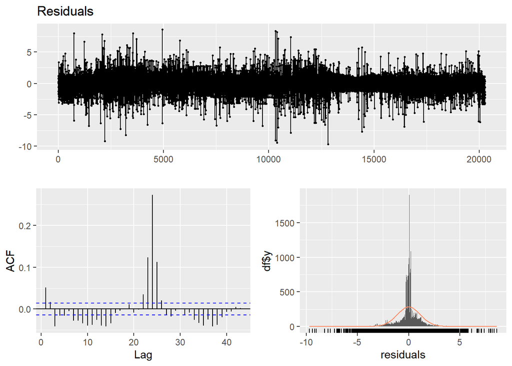

```
##
##  Breusch-Godfrey test for serial correlation of order up to 39
##
## data:  Residuals
## LM test = 2166.8, df = 39, p-value < 2.2e-16
```

```r
checkresiduals(lm_demo4)
```

```r
#lm_demo4 with variables
lm_demo4_1=lm(production~lag1+hour +average_DSWRF_surface,data = model)
summary(lm_demo4_1)
```

```
##
## Call:
## lm(formula = production ~ lag1 + hour + average_DSWRF_surface,
##     data = model)
##
## Residuals:
##     Min      1Q  Median      3Q     Max
## -9.8207 -0.1206  0.0000  0.3262  8.5713
##
## Coefficients:
##                         Estimate Std. Error t value Pr(>|t|)
## (Intercept)            5.283e-13  3.919e-02   0.000  1.00000
## lag1                   7.625e-01  4.980e-03 153.120  < 2e-16 ***
## hour1                 -3.986e-14  5.543e-02   0.000  1.00000
## hour10                 1.909e+00  6.454e-02  29.574  < 2e-16 ***
## hour11                 1.484e+00  6.640e-02  22.353  < 2e-16 ***
## hour12                 1.267e+00  6.745e-02  18.786  < 2e-16 ***
## hour13                 8.843e-01  6.801e-02  13.003  < 2e-16 ***
## hour14                 1.369e-01  6.784e-02   2.017  0.04366 *
## hour15                -8.496e-01  6.676e-02 -12.726  < 2e-16 ***
## hour16                -1.523e+00  6.200e-02 -24.571  < 2e-16 ***
## hour17                -1.303e+00  5.993e-02 -21.737  < 2e-16 ***
## hour18                -8.440e-01  5.880e-02 -14.354  < 2e-16 ***
## hour19                -2.736e-01  5.795e-02  -4.722 2.36e-06 ***
## hour2                 -3.555e-15  5.543e-02   0.000  1.00000
## hour20                -1.786e-01  5.712e-02  -3.127  0.00177 **
## hour21                -1.488e-01  5.661e-02  -2.629  0.00857 **
## hour22                 1.420e-14  5.543e-02   0.000  1.00000
## hour23                -7.312e-14  5.543e-02   0.000  1.00000
## hour3                 -1.540e-13  5.543e-02   0.000  1.00000
## hour4                  4.284e-03  5.541e-02   0.077  0.93838
## hour5                  5.366e-02  5.541e-02   0.968  0.33291
## hour6                  5.406e-01  5.541e-02   9.755  < 2e-16 ***
## hour7                  2.281e+00  5.548e-02  41.124  < 2e-16 ***
## hour8                  3.276e+00  5.682e-02  57.648  < 2e-16 ***
## hour9                  3.111e+00  6.061e-02  51.333  < 2e-16 ***
## average_DSWRF_surface  9.084e-04  7.013e-05  12.953  < 2e-16 ***
## ---
## Signif. codes:  0 '***' 0.001 '**' 0.01 '*' 0.05 '.' 0.1 ' ' 1
##
## Residual standard error: 1.139 on 20241 degrees of freedom
##   (1 observation deleted due to missingness)
## Multiple R-squared:  0.9051, Adjusted R-squared:  0.905
## F-statistic:  7723 on 25 and 20241 DF,  p-value: < 2.2e-16
```

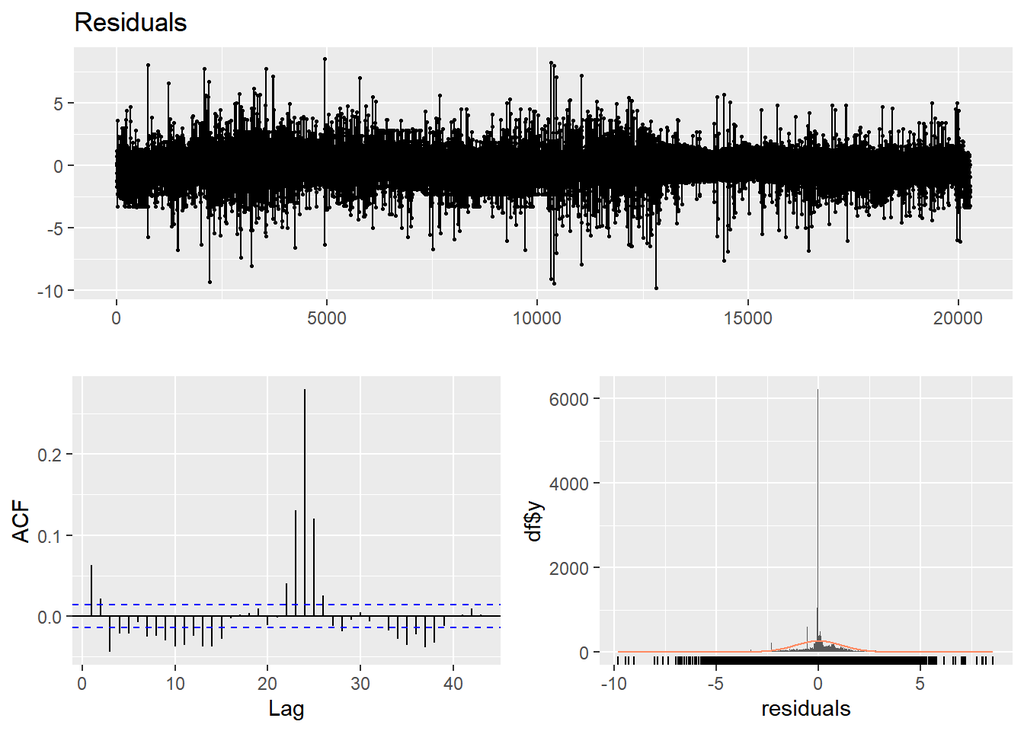

```
##
##  Breusch-Godfrey test for serial correlation of order up to 29
##
## data:  Residuals
## LM test = 2330.5, df = 29, p-value < 2.2e-16
```

```r
checkresiduals(lm_demo4_1)
```

At that phase,we decided to continue in lm_demo1_1 since it has highest R^2 and applicable. At that graph we compared lm_demo1_1 prediction to actual data.Then we checked the residuals again. We see that, we failed to predict winter-fall season. On the other hand spring-summer season we made predict on that at competition phase seems like fiting.

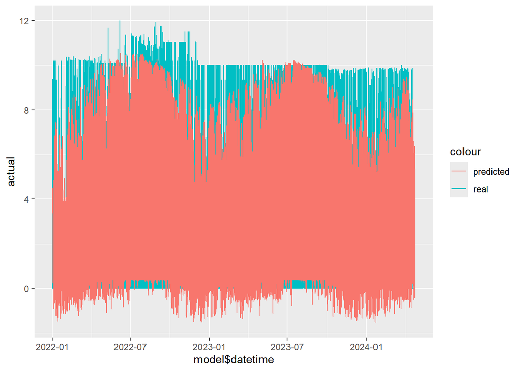

```r
tmp1 <- copy(model)
tmp1$actual <- model$production
tmp1$predicted_trend <- predict(lm_demo1_1, tmp1)
tmp1$residual_trend <- tmp1$actual - tmp1$predicted_trend

# Plot the data
ggplot(tmp1, aes(x = model$datetime)) +
  geom_line(aes(y = actual, color = 'real')) +
  geom_line(aes(y = predicted_trend, color = 'predicted'))
```

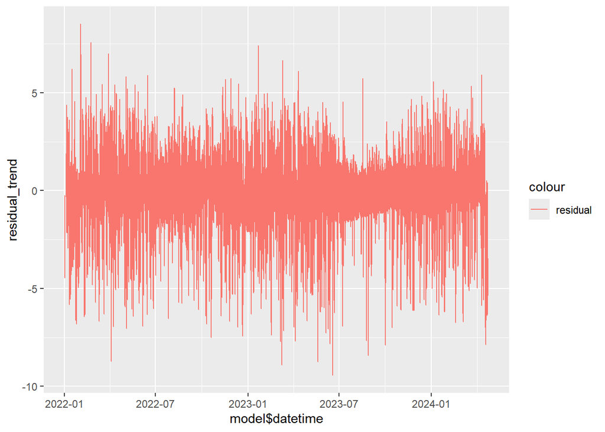

```r
ggplot(tmp1, aes(x = model$datetime)) +
  geom_line(aes(y = residual_trend, color = 'residual'))
```

## Arima Models

From here we tried to develop arima models. Since we used autoregressive parameters at linear models, we can continue on differencing and moving average terms. First of all we tried autoarima and suggested model is (3,1,4). However the model is not seasonal and similar problems from linear model seen. Then we tried (3,1,4)(0,0,6)24 seasonal arima. We decided to use 6 seasonal moving average because within every 24 hour we saw 6 negative value autocorelation lag. Then we coluldn’t find any model better than lm_demo1_1

```r
#Whole Period Arima
arima_model <- auto.arima(model$production,seasonal = TRUE)
summary(arima_model)
```

```
## Series: model$production
## ARIMA(3,1,4)
##
## Coefficients:
##          ar1      ar2      ar3      ma1      ma2     ma3     ma4
##       1.4451  -0.1764  -0.3683  -1.3641  -0.0012  0.2729  0.1061
## s.e.  0.0767   0.1425   0.0714   0.0761   0.1377  0.0579  0.0093
##
## sigma^2 = 1.789:  log likelihood = -34648.66
## AIC=69313.31   AICc=69313.32   BIC=69376.65
##
## Training set error measures:
##                        ME     RMSE       MAE MPE MAPE     MASE         ACF1
## Training set -0.001334752 1.337162 0.8999631 NaN  Inf 1.077383 -0.001194286
```

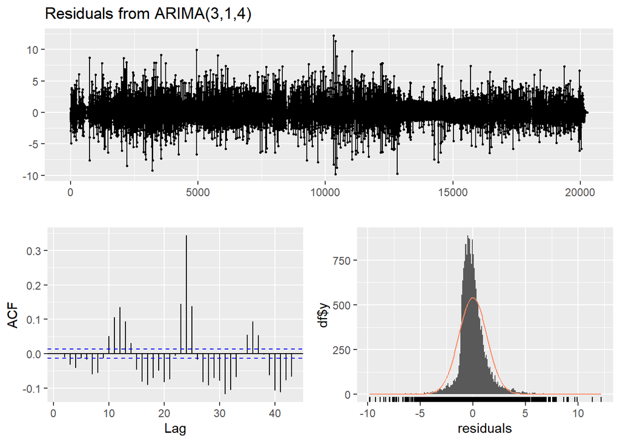

```
##
##  Ljung-Box test
##
## data:  Residuals from ARIMA(3,1,4)
## Q* = 263.52, df = 3, p-value < 2.2e-16
##
## Model df: 7.   Total lags used: 10
```

```r
checkresiduals(arima_model)
```

```r
#Whole Period Arima with 1 more MA
arima_model_1 <- arima(model$production,order = c(3L,1L,4L),seasonal = list(order = c(0L,0L,6L),period = 24))
summary(arima_model_1)
```

```
##
## Call:
## arima(x = model$production, order = c(3L, 1L, 4L), seasonal = list(order = c(0L,
##     0L, 6L), period = 24))
##
## Coefficients:
##          ar1     ar2      ar3      ma1      ma2     ma3      ma4    sma1
##       0.8183  0.7816  -0.7249  -0.9688  -0.7723  0.7923  -0.0502  0.3064
## s.e.  0.0170  0.0332   0.0171   0.0167   0.0386  0.0278   0.0088  0.0072
##         sma2    sma3    sma4    sma5    sma6
##       0.2788  0.2298  0.1977  0.1661  0.1364
## s.e.  0.0075  0.0075  0.0068  0.0065  0.0067
##
## sigma^2 estimated as 1.359:  log likelihood = -31872.2,  aic = 63772.4
##
## Training set error measures:
##                        ME     RMSE       MAE MPE MAPE      MASE         ACF1
## Training set -0.001158568 1.165704 0.7193264 NaN  Inf 0.8611351 -0.003475049
```

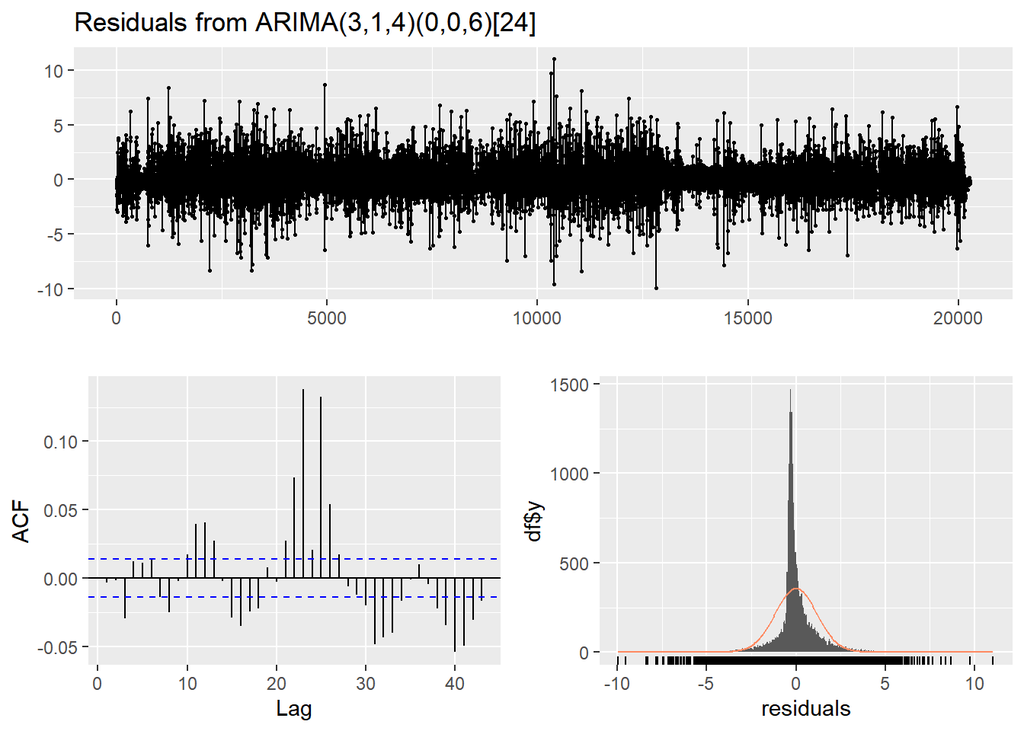

```
##
##  Ljung-Box test
##
## data:  Residuals from ARIMA(3,1,4)(0,0,6)[24]
## Q* = 173.5, df = 3, p-value < 2.2e-16
##
## Model df: 13.   Total lags used: 16
```

```r
checkresiduals(arima_model_1)
```

## Prediction Phase

At competition phase given code used to predict T+1 period ahead production. Generally lm_deme1_1 used if we have 48 hour before production. Otherwise lm_demo3_1 is the other alternative for us.

```r
data_production <- read.csv("C:\\Users\\Berke\\Desktop\\production_predict.csv")
data_weather <- read.csv("C:\\Users\\Berke\\Desktop\\processed_weather.csv")
data_production <- data.table(data_production)
data_weather <- data.table(data_weather)


data_production[,datetime:=ymd(date) + dhours(hour)]
data_weather[,datetime:=ymd(date) + dhours(hour)]

data_production$date <- as.Date(data_production$date)
#data_production$hour <- paste(data_production$hour)
data_weather$date <- as.Date(data_weather$date)
#data_weather$hour <- paste(data_weather$hour)

#dataxts <- xts(data_production[,"production"], order.by=data_production[,"datetime"])

#average of all panels, instead of the code above
weather_avg <- data_weather %>%
  group_by(datetime) %>%
  summarise(
    average_DSWRF_surface = mean(dswrf_surface, na.rm = TRUE),
    average_TCDC_low.cloud.layer = mean(data_weather$tcdc_low.cloud.layer, na.rm = TRUE),
    average_TCDC_middle.cloud.layer = mean(tcdc_middle.cloud.layer, na.rm = TRUE),
    average_TCDC_high.cloud.layer = mean(tcdc_high.cloud.layer, na.rm = TRUE),
    average_TCDC_entire.atmosphere = mean(tcdc_entire.atmosphere, na.rm = TRUE),
    average_USWRF_top.of.atmosphere = mean(uswrf_top_of_atmosphere, na.rm = TRUE),
    average_CSNOW.surface = mean(csnow_surface, na.rm = TRUE),
    average_DLWRF.surface = mean(dlwrf_surface, na.rm = TRUE),
    average_USWRF.surface = mean(uswrf_surface, na.rm = TRUE),
    average_TMP.surface = mean(tmp_surface, na.rm = TRUE),
  )
weather_avg <- full_join(data_production,weather_avg,by='datetime')
head(weather_avg)
```

```
##          date  hour production            datetime average_DSWRF_surface
##        <Date> <int>      <num>              <POSc>                 <num>
## 1: 2022-01-01     0          0 2022-01-01 00:00:00                    NA
## 2: 2022-01-01     1          0 2022-01-01 01:00:00                    NA
## 3: 2022-01-01     2          0 2022-01-01 02:00:00                    NA
## 4: 2022-01-01     3          0 2022-01-01 03:00:00                    NA
## 5: 2022-01-01     4          0 2022-01-01 04:00:00                     0
## 6: 2022-01-01     5          0 2022-01-01 05:00:00                     0
##    average_TCDC_low.cloud.layer average_TCDC_middle.cloud.layer
##                           <num>                           <num>
## 1:                           NA                              NA
## 2:                           NA                              NA
## 3:                           NA                              NA
## 4:                           NA                              NA
## 5:                     21.58126                           5.944
```

[output cut: 25 more lines]

```r
model_p <-weather_avg %>% select(datetime,production,average_TCDC_entire.atmosphere,average_USWRF.surface,average_TMP.surface,average_DSWRF_surface)

model_p$day <- yday(model_p$datetime)
model_p$hour <- hour(model_p$datetime)
model_p$month <- month(model_p$datetime)

model_p$day <- as.character(model_p$day)
model_p$hour <- as.character(model_p$hour)
model_p$month <- as.character(model_p$month)

model_p[is.na(model_p)] <- 0
len48 <- (length(model_p$datetime)-48)
len49 <- (length(model_p$datetime)-49)
len47 <- (length(model_p$datetime)-47)
len72 <- (length(model_p$datetime)-72)
model_p$lag48[49:length(model_p$datetime)] = model_p$production[1:len48]
model_p$lag49[50:length(model_p$datetime)] = model_p$production[1:len49]
model_p$lag47[48:length(model_p$datetime)] = model_p$production[1:len47]
model_p$lag72[73:length(model_p$datetime)] = model_p$production[1:len72]
summary(model)
```

```
##     datetime                        production
##  Min.   :2022-01-01 04:00:00.00   Min.   : 0.000
##  1st Qu.:2022-07-31 06:45:00.00   1st Qu.: 0.000
##  Median :2023-02-26 09:30:00.00   Median : 0.000
##  Mean   :2023-02-26 16:41:41.24   Mean   : 2.553
##  3rd Qu.:2023-09-25 12:15:00.00   3rd Qu.: 5.100
##  Max.   :2024-04-22 15:00:00.00   Max.   :12.000
##
##  average_TCDC_entire.atmosphere average_USWRF.surface average_TMP.surface
##  Min.   :  0.000                Min.   :  0.00        Min.   :  0.0
##  1st Qu.:  3.627                1st Qu.:  0.00        1st Qu.:275.7
##  Median : 40.178                Median : 18.09        Median :282.9
##  Mean   : 44.760                Mean   : 49.34        Mean   :284.2
##  3rd Qu.: 84.680                3rd Qu.: 89.63        3rd Qu.:290.7
##  Max.   :100.000                Max.   :441.61        Max.   :323.2
##
##  average_DSWRF_surface     day                hour              month
##  Min.   :  0.00        Length:20268       Length:20268       Length:20268
##  1st Qu.:  0.00        Class :character   Class :character   Class :character
##  Median : 75.04        Mode  :character   Mode  :character   Mode  :character
##  Mean   :215.65
##  3rd Qu.:386.66
##  Max.   :949.66
##
##      lag48            lag49            lag47            lag72
##  Min.   : 0.000   Min.   : 0.000   Min.   : 0.000   Min.   : 0.000
##  1st Qu.: 0.000   1st Qu.: 0.000   1st Qu.: 0.000   1st Qu.: 0.000
##  Median : 0.000   Median : 0.000   Median : 0.000   Median : 0.000
##  Mean   : 2.559   Mean   : 2.559   Mean   : 2.559   Mean   : 2.562
##  3rd Qu.: 5.100   3rd Qu.: 5.100   3rd Qu.: 5.100   3rd Qu.: 5.100
##  Max.   :12.000   Max.   :12.000   Max.   :12.000   Max.   :12.000
##  NA's   :48       NA's   :49       NA's   :47       NA's   :72
##       lag1
##  Min.   : 0.000
##  1st Qu.: 0.000
##  Median : 0.000
##  Mean   : 2.553
##  3rd Qu.: 5.100
##  Max.   :12.000
##  NA's   :1
```

```r
model_predict <- subset(model_p,datetime >= as.POSIXct("2024-05-27 00:00:00",tz = "UTC") & datetime <= as.POSIXct("2024-05-28 00:00:00",tz = "UTC"))
tail(model_predict,48)
```

```
##                datetime production average_TCDC_entire.atmosphere
##                  <POSc>      <num>                          <num>
##  1: 2024-05-27 00:00:00          0                         58.020
##  2: 2024-05-27 01:00:00          0                         61.348
##  3: 2024-05-27 02:00:00          0                         62.052
##  4: 2024-05-27 03:00:00          0                         61.684
##  5: 2024-05-27 04:00:00          0                         60.804
##  6: 2024-05-27 05:00:00          0                         62.648
##  7: 2024-05-27 06:00:00          0                         67.868
##  8: 2024-05-27 07:00:00          0                         70.064
##  9: 2024-05-27 08:00:00          0                         74.724
## 10: 2024-05-27 09:00:00          0                         77.008
## 11: 2024-05-27 10:00:00          0                         82.164
## 12: 2024-05-27 11:00:00          0                         89.960
## 13: 2024-05-27 12:00:00          0                         92.116
```

[output cut: 69 more lines]

```r
#If you have day before production use that
linear_regression_prediction <- predict(lm_demo1_1, newdata = model_predict) # test verisi bul
result <- data.frame(linear_regression_prediction,model_predict$production)
result
```

```
##    linear_regression_prediction model_predict.production
## 1                    -0.1328358                        0
## 2                    -0.1699640                        0
## 3                    -0.1814935                        0
## 4                    -0.1800540                        0
## 5                    -0.1718242                        0
## 6                    -0.1526203                        0
## 7                     0.1521036                        0
## 8                     1.9430404                        0
## 9                     3.6535533                        0
## 10                    5.2563290                        0
## 11                    5.8371460                        0
## 12                    6.0454262                        0
## 13                    6.1399604                        0
## 14                    5.5125859                        0
## 15                    4.1758428                        0
## 16                    2.7979997                        0
## 17                    0.7891675                        0
## 18                   -0.1669171                        0
## 19                   -0.4921234                        0
## 20                   -0.3753608                        0
## 21                   -0.2615031                        0
## 22                   -0.1644601                        0
## 23                    0.3631803                        0
## 24                    0.3712102                        0
## 25                    0.3694476                        0
```

```r
#If you don't have day before production use that
linear_regression_prediction <- predict(lm_demo3_1, newdata = model_predict) # test verisi bul
result <- data.frame(linear_regression_prediction,model_predict$production)
result
```

```
##    linear_regression_prediction model_predict.production
## 1                    0.11143461                        0
## 2                    0.05562415                        0
## 3                    0.03928811                        0
## 4                    0.04204016                        0
## 5                    0.05436033                        0
## 6                    0.07066000                        0
## 7                    0.37454896                        0
## 8                    2.59457150                        0
## 9                    4.41071836                        0
## 10                   6.43028086                        0
## 11                   6.13548392                        0
## 12                   6.77776698                        0
## 13                   7.24440325                        0
## 14                   6.52242839                        0
## 15                   4.78490675                        0
## 16                   3.24583350                        0
## 17                   1.51792480                        0
## 18                   0.36986064                        0
## 19                  -0.17885631                        0
## 20                  -0.15889079                        0
## 21                  -0.02698749                        0
## 22                   0.11418472                        0
## 23                   0.88577305                        0
## 24                   0.89837671                        0
## 25                   0.89622140                        0
```

## Conclusion:

All methods are applied then their results are considered according to some different aspects. The method chosen as the most effective method for the project is the one that predicts the production for the next day based on the actual production that occurred 48 and/or 72 hours earlier. To make predictions of production, we use real data for past days and also we use other predictions for weather conditions. Blend of real data and weather predictions are the effective elements for our prediction mechanism. Therefore, reaching the optimal prediction is impossible as weather predictions don’t realize a perfect efficiency.

Lastly, all these elements are considered and the last version of our model created to use competition phase by using: -48 and/or 72 hours earlier production data. -Total cloudiness of the weather(TCDC_entire.atmosphere) -Total radiation flux(DSWRF_surface) -hour dummy variable